# site-specific characterization

Scott Coffin

7/23/2021

#Intro The objective of this project is to determine site-specific SSDs for plastic particles spiked into the experimental lakes area in Canada. Particle distribution data for added plastic particles is from Chelsea Rochman.

Some notes: all particles are fragments. These started as pellets and were ground down with a toll grinder under liquid nitrogen.

Chelsea is not 100% certain that the lower size ranges are real. In fact, they measured them two ways. The first was the toll grinding company measuring their sizes with sieve stacks – and seeing how much fell in each size range. The second was us taking images of different amounts (masses) of plastics and counting and measuring each particle. We did the latter to figure out what mass we needed to dose with to achieve the particle count we wanted. We also did it to confirm size. The two methods are pretty similar in results. Anything smaller we could not have measured well and neither could the toll grinding company, so it’s hard to say. As such, Chelsea is comfortable with us extrapolating to 1 micron.

Chelsea knows what kinds of species are in the lake. For fish: yellow perch; for invertebrates: a range of zooplankton varying in size – including chaoberus, daphnia, copepods (and others! – do you need genus species or just lots of species of zooplankton is okay?); phytoplankton and periphyton communities.

# 1 Setup

## 1.1 Libraries

```r
library(tidyverse)
library(ssdtools)
library(fitdistrplus)
library(rbin)
```

## 1.2 Import data

```r
#site-specific distribution data
distributions <- read.csv("Concentration data/site-specific distributions/SizeMicroplastic_Rochman.csv") %>%
  rename("polymer" = "ï..PolymerType")
```

# 2 Modelling

## 2.1 Visualization

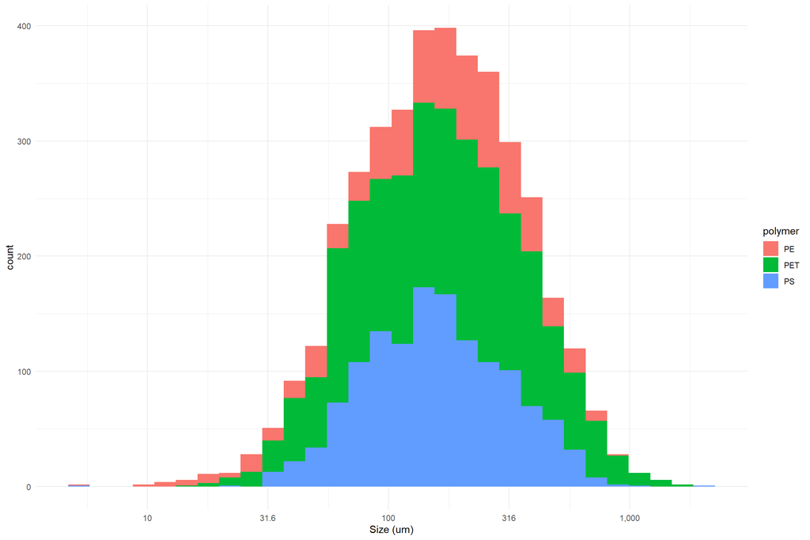

```r
distributions %>%
  ggplot(aes(x = Size_um, fill = polymer)) +
  geom_histogram() +
  scale_x_continuous(name = "Size (um)",breaks = scales::trans_breaks("log10", function(x) 10^x),labels = comma_signif, trans = "log10")+
  theme_minimal()
```

We can see here that they do not exactly follow an alpha distribution, but this is likely due to detection limits.

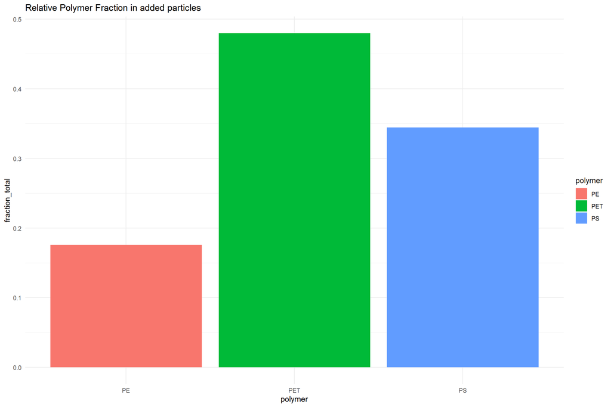

```r
distributions %>%
  group_by(polymer) %>%
  summarize(count = n()) %>%
  mutate(fraction_total = count /  sum(count)) %>%
  ggplot(aes(x = polymer, y = fraction_total, fill = polymer)) +
  geom_col() +
  labs(title = "Relative Polymer Fraction in added particles") +
  theme_minimal()
```

### 2.1.1 Average Density

```r
library(skimr)
distributions %>%
  mutate(density = case_when(polymer == "PE" ~ 0.91,
                             polymer == "PET" ~ 1.38,
                             polymer == "PS" ~ 1.04)) %>%
   #filter(Size_um >150
    #     & Size_um <1000) %>%
  skim()
```

Data summary

| Name | Piped data |
| --- | --- |
| Number of rows | 3947 |
| Number of columns | 4 |
| _______________________ |  |
| Column type frequency: |  |
| character | 1 |
| numeric | 3 |
| ________________________ |  |
| Group variables | None |

**Variable type: character**

| skim_variable | n_missing | complete_rate | min | max | empty | n_unique | whitespace |
| --- | --- | --- | --- | --- | --- | --- | --- |
| polymer | 0 | 1 | 2 | 3 | 0 | 3 | 0 |

**Variable type: numeric**

| skim_variable | n_missing | complete_rate | mean | sd | p0 | p25 | p50 | p75 | p100 | hist |
| --- | --- | --- | --- | --- | --- | --- | --- | --- | --- | --- |
| Size_cm | 0 | 1 | 0.02 | 0.02 | 0.00 | 0.01 | 0.02 | 0.03 | 0.20 | ▇▁▁▁▁ |
| Size_um | 0 | 1 | 215.95 | 179.02 | 5.00 | 94.00 | 162.00 | 281.00 | 1960.00 | ▇▁▁▁▁ |
| density | 0 | 1 | 1.18 | 0.20 | 0.91 | 1.04 | 1.04 | 1.38 | 1.38 | ▃▆▁▁▇ |

## 2.2 Determine maximum size for which the dataset

The maximum size for which the dataset was valid is determined using a theoretical particle detection limit (PDL).

1. Data was plotted using only the values between the minimum and the first non-detect. A log-log plot for size vs abundance (#) is made.
2. A linear trendline was fitted, and the parameters for the function y = a*x + b were obtained
3. Assuming y = 0 (equals 1 particle since 10^0 = 1), a value for x (the PDL) was calculated
4. Data were plotted using only the values between the minimum and the calculated PDL
5. If more data were included than in step 1, the procedure was repeated.
6. Once the PDL does not change anymore, only data between the minimum and PDL were included for the final trendline fitting.

```r
#first split dataset into polymers
PS <- distributions %>%
  filter(polymer == "PS")
PET <- distributions %>%
  filter(polymer == "PET")
PE <- distributions %>%
  filter(polymer == "PE")
```

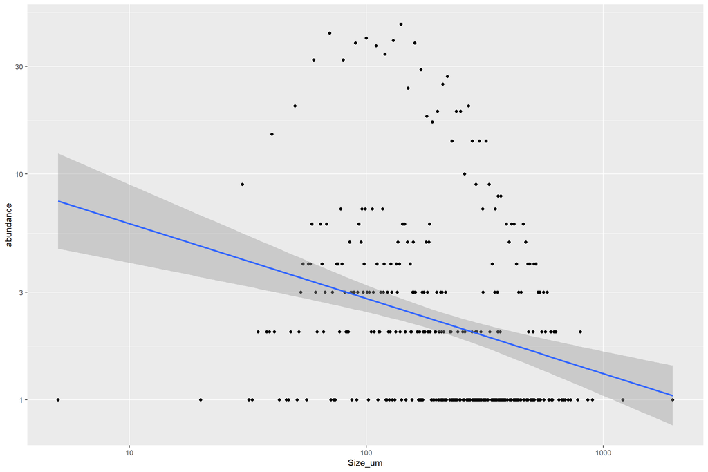

```r
# #cut data into bins to add frequency column to alllow for plotting
# PS %>% summarize(min_size = min(Size_um), max = max(Size_um))
#
# breaks <- c(5:1960)
# PS$bins <- cut(PS$Size_um, breaks = breaks)
#
# PS %>%
#   group_by(bins) %>%
#   summarize(abundance = n())

# ## alt approach
# PS$bins <- .bincode(PS$Size_um, breaks = breaks)

PS_abundance <- PS %>%
  group_by(Size_um) %>%
  summarize(abundance = n())

PS_abundance %>%
  ggplot(aes(x = Size_um, y = abundance)) +
  geom_point() +
  geom_smooth(method = "lm") +
  scale_x_log10() +
  scale_y_log10()
```

We need a better way of binning data.

Winsorized binning is similar to equal length binning except that both tails are cut off to obtain a smooth binning result. This technique is often used to remove outliers during the data pre-processing stage. For Winsorized binning, the Winsorized statistics are computed first. After the minimum and maximum have been found, the split points are calculated the same way as in equal length binning.

### 2.2.1 Polystyrene

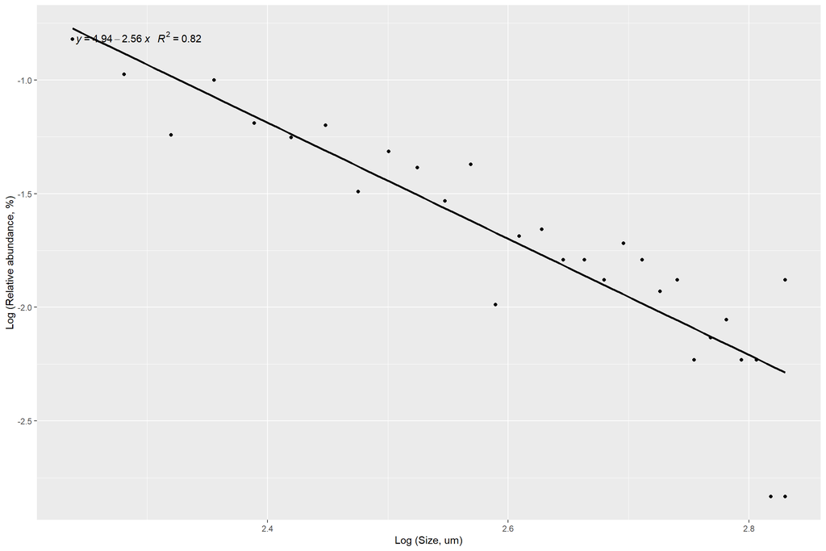

```r
#determine lower and upper end based on maximum R^2 (iteration required)
PS_cut <- PS %>%
  filter(Size_um >150
         & Size_um <1000)

#cut into bins
#PSwinsors <- rbin_winsorize(PS_cut, polymer, Size_um, 20)
PSwinsors <- rbin_winsorize(PS_cut, polymer, Size_um, 30, winsor_rate = 0.01)
#save as dataframe
PSbinned <- as.data.frame(PSwinsors$bins) %>%
  dplyr::select(c(cut_point, bin_count, bin_prop))

#strip of characters
PSbinned$cut <- gsub("[^0-9.-]","",PSbinned$cut_point)
 #convert to numeric
PSbinned2 <- PSbinned %>%
  mutate(cut.numeric = as.numeric(cut)) %>%
  mutate(logAbundance = log10(bin_prop),
         logSize = log10(cut.numeric))

## model
library(ggpmisc)
my.formula <- y ~ x
p <- ggplot(data = PSbinned2, aes(x = logSize, y = logAbundance)) +
   geom_smooth(method = "lm", se=FALSE, color="black", formula = my.formula) +
   stat_poly_eq(formula = my.formula,
                aes(label = paste(..eq.label.., ..rr.label.., sep = "~~~")),
                parse = TRUE) +
   geom_point() +
  xlab("Log (Size, um)") +
  ylab("Log (Relative abundance, %)")
p
```

#### Remove outliers

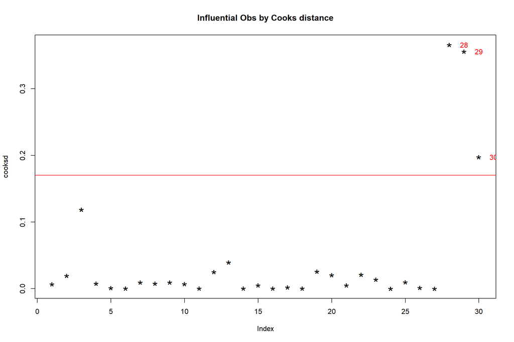

```r
PSlin <- lm(logAbundance ~ logSize, data = PSbinned2)
cooksd <- cooks.distance(PSlin)
plot(cooksd, pch="*", cex=2, main="Influential Obs by Cooks distance")  # plot cook's distance
abline(h = 4*mean(cooksd, na.rm=T), col="red")  # add cutoff line
text(x=1:length(cooksd)+1, y=cooksd, labels=ifelse(cooksd>4*mean(cooksd, na.rm=T),names(cooksd),""), col="red")  # add labels
```

Extract outliers

```r
influential <- as.numeric(names(cooksd)[(cooksd > 4*mean(cooksd, na.rm=T))])  # influential row numbers
head(PSbinned2[influential, ])  # influential observations.
```

```
##              cut_point bin_count    bin_prop              cut cut.numeric
## 28  < 658.066666666668         1 0.001468429 658.066666666668    658.0667
## 29  < 676.033333333334         1 0.001468429 676.033333333334    676.0333
## 30 >= 676.033333333334         9 0.013215859 676.033333333334    676.0333
##    logAbundance  logSize
## 28    -2.833147 2.818270
## 29    -2.833147 2.829968
## 30    -1.878905 2.829968
```

```r
trimmedPS <- PSbinned2 %>%
  filter(cut_point != c("   < 658.066666666668", "< 676.033333333334", ">= 676.033333333334")
) %>%
  mutate(polymer = "PS")

PSlin <- lm(logAbundance ~ logSize, data = trimmedPS)
PSlin.summ <- summary(PSlin)
PSlin.summ
```

```
##
## Call:
## lm(formula = logAbundance ~ logSize, data = trimmedPS)
##
## Residuals:
##      Min       1Q   Median       3Q      Max
## -0.59149 -0.04016  0.02279  0.10783  0.24439
##
## Coefficients:
##             Estimate Std. Error t value Pr(>|t|)
## (Intercept)   4.8391     0.5173   9.354 8.36e-10 ***
## logSize      -2.5124     0.1994 -12.598 1.42e-12 ***
## ---
## Signif. codes:  0 '***' 0.001 '**' 0.01 '*' 0.05 '.' 0.1 ' ' 1
##
## Residual standard error: 0.1768 on 26 degrees of freedom
## Multiple R-squared:  0.8592, Adjusted R-squared:  0.8538
## F-statistic: 158.7 on 1 and 26 DF,  p-value: 1.417e-12
```

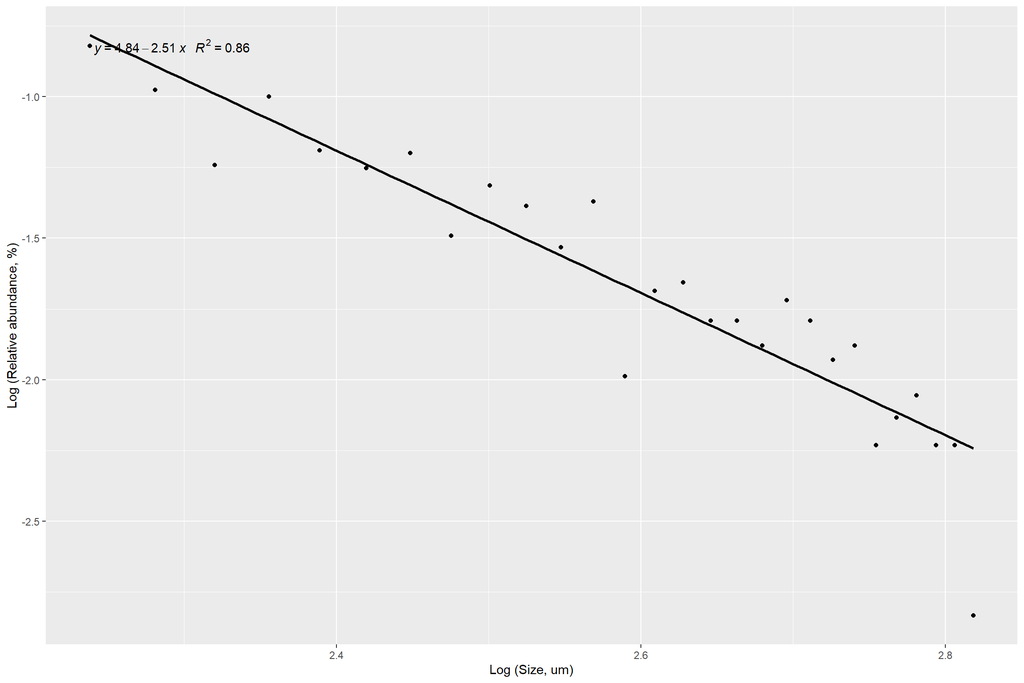

```r
ggplot(data = trimmedPS, aes(x = logSize, y = logAbundance)) +
   geom_smooth(method = "lm", se=FALSE, color="black", formula = my.formula) +
   stat_poly_eq(formula = my.formula,
                aes(label = paste(..eq.label.., ..rr.label.., sep = "~~~")),
                parse = TRUE) +
   geom_point() +
  xlab("Log (Size, um)") +
  ylab("Log (Relative abundance, %)")
```

### 2.2.2 PET

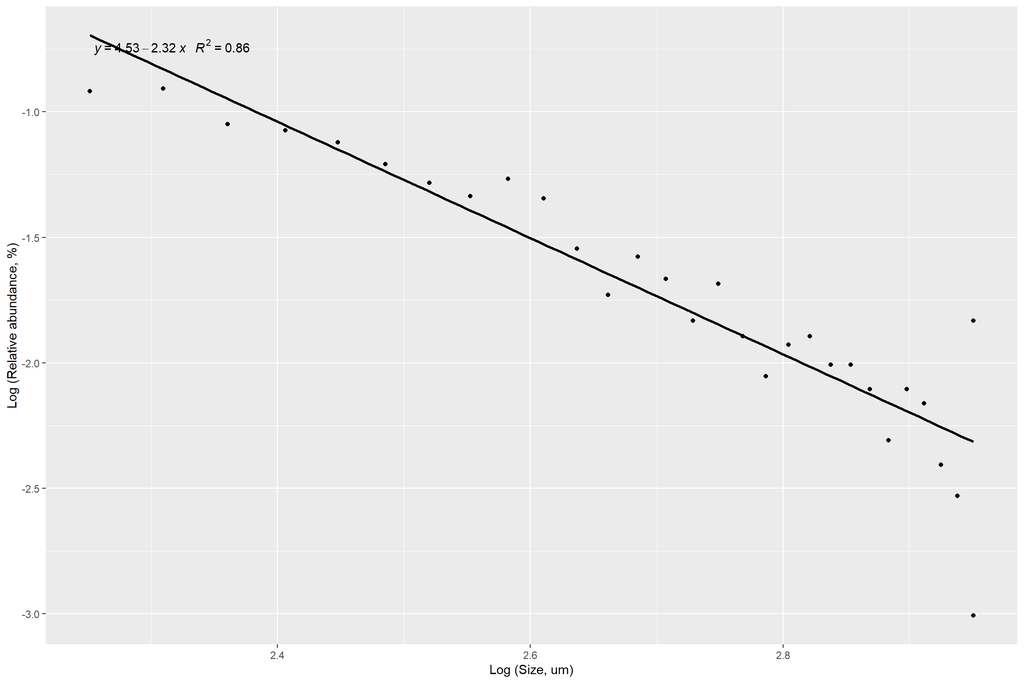

```r
#determine lower and upper end based on maximum R^2 (iteration required)
PET_cut <- PET %>%
  filter(Size_um >150 & Size_um <1000)

#cut into bins
#PETwinsors <- rbin_winsorize(PET_cut, polymer, Size_um, 20)
PETwinsors <- rbin_winsorize(PET_cut, polymer, Size_um, 30, winsor_rate = 0.01)
#save as dataframe
PETbinned <- as.data.frame(PETwinsors$bins) %>%
  dplyr::select(c(cut_point, bin_count, bin_prop))

#strip of characters
PETbinned$cut <- gsub("[^0-9.-]","",PETbinned$cut_point)
 #convert to numeric
PETbinned2 <- PETbinned %>%
  mutate(cut.numeric = as.numeric(cut)) %>%
  mutate(logAbundance = log10(bin_prop),
         logSize = log10(cut.numeric))

## model
library(ggpmisc)
my.formula <- y ~ x
p <- ggplot(data = PETbinned2, aes(x = logSize, y = logAbundance)) +
   geom_smooth(method = "lm", se=FALSE, color="black", formula = my.formula) +
   stat_poly_eq(formula = my.formula,
                aes(label = paste(..eq.label.., ..rr.label.., sep = "~~~")),
                parse = TRUE) +
   geom_point() +
  xlab("Log (Size, um)") +
  ylab("Log (Relative abundance, %)")
p
```

#### Remove outliers

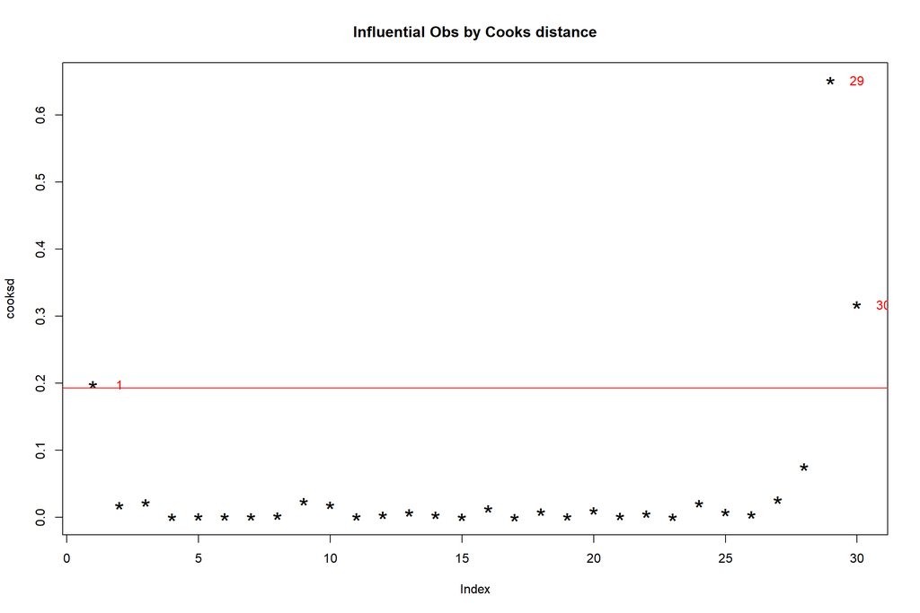

```r
PETlin <- lm(logAbundance ~ logSize, data = PETbinned2)
cooksd <- cooks.distance(PETlin)
plot(cooksd, pch="*", cex=2, main="Influential Obs by Cooks distance")  # plot cook's distance
abline(h = 4*mean(cooksd, na.rm=T), col="red")  # add cutoff line
text(x=1:length(cooksd)+1, y=cooksd, labels=ifelse(cooksd>4*mean(cooksd, na.rm=T),names(cooksd),""), col="red")  # add labels
```

Extract outliers

```r
influential <- as.numeric(names(cooksd)[(cooksd > 4*mean(cooksd, na.rm=T))])  # influential row numbers
head(PETbinned2[influential, ])  # influential observations.
```

```
##              cut_point bin_count     bin_prop              cut cut.numeric
## 1   < 178.476666666667       123 0.1208251473 178.476666666667    178.4767
## 29  < 891.823333333334         1 0.0009823183 891.823333333334    891.8233
## 30 >= 891.823333333334        15 0.0147347741 891.823333333334    891.8233
##    logAbundance  logSize
## 1    -0.9178427 2.251581
## 29   -3.0077478 2.950279
## 30   -1.8316565 2.950279
```

```r
trimmedPET <- PETbinned2 %>%
  filter(cut_point != c("       < 178.476666666667", "  < 891.823333333334", ">= 891.823333333334")
)%>%
  mutate(polymer = "PET")

PETlin <- lm(logAbundance ~ logSize, data = trimmedPET)
PETlin.summ <- summary(PETlin)
PETlin.summ
```

```
##
## Call:
## lm(formula = logAbundance ~ logSize, data = trimmedPET)
##
## Residuals:
##      Min       1Q   Median       3Q      Max
## -0.64693 -0.09074  0.03254  0.10510  0.19957
##
## Coefficients:
##             Estimate Std. Error t value Pr(>|t|)
## (Intercept)   4.8075     0.4389   10.95 1.94e-11 ***
## logSize      -2.4297     0.1629  -14.92 1.47e-14 ***
## ---
## Signif. codes:  0 '***' 0.001 '**' 0.01 '*' 0.05 '.' 0.1 ' ' 1
##
## Residual standard error: 0.1739 on 27 degrees of freedom
## Multiple R-squared:  0.8918, Adjusted R-squared:  0.8878
## F-statistic: 222.6 on 1 and 27 DF,  p-value: 1.466e-14
```

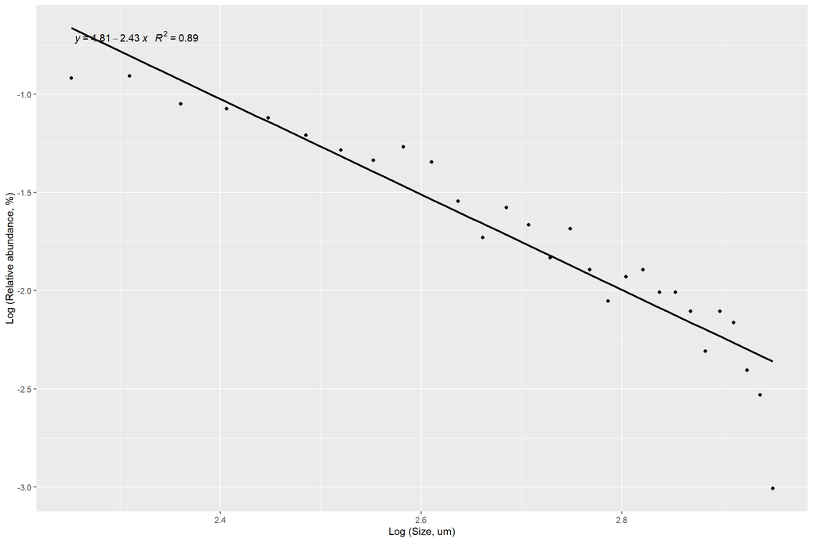

```r
ggplot(data = trimmedPET, aes(x = logSize, y = logAbundance)) +
   geom_smooth(method = "lm", se=FALSE, color="black", formula = my.formula) +
   stat_poly_eq(formula = my.formula,
                aes(label = paste(..eq.label.., ..rr.label.., sep = "~~~")),
                parse = TRUE) +
   geom_point() +
  xlab("Log (Size, um)") +
  ylab("Log (Relative abundance, %)")
```

### 2.2.3 PE

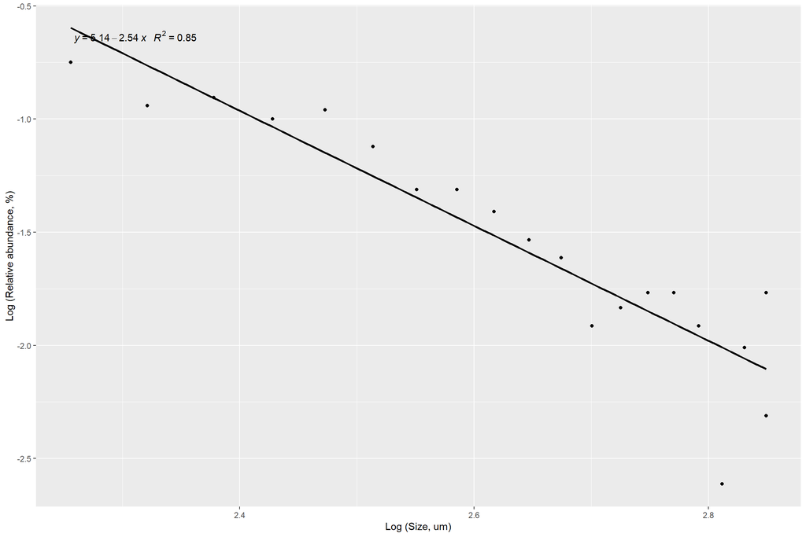

```r
#determine lower and upper end based on maximum R^2 (iteration required)
PE_cut <- PE %>%
  filter(Size_um >150 & Size_um <1000)

#cut into bins
#PEwinsors <- rbin_winsorize(PE_cut, polymer, Size_um, 20)
PEwinsors <- rbin_winsorize(PE_cut, polymer, Size_um, 20, winsor_rate = 0.01)
#save as dataframe
PEbinned <- as.data.frame(PEwinsors$bins) %>%
  dplyr::select(c(cut_point, bin_count, bin_prop))

#strip of characters
PEbinned$cut <- gsub("[^0-9.-]","",PEbinned$cut_point)
 #convert to numeric
PEbinned2 <- PEbinned %>%
  mutate(cut.numeric = as.numeric(cut)) %>%
  mutate(logAbundance = log10(bin_prop),
         logSize = log10(cut.numeric))

## model
library(ggpmisc)
my.formula <- y ~ x
p <- ggplot(data = PEbinned2, aes(x = logSize, y = logAbundance)) +
   geom_smooth(method = "lm", se=FALSE, color="black", formula = my.formula) +
   stat_poly_eq(formula = my.formula,
                aes(label = paste(..eq.label.., ..rr.label.., sep = "~~~")),
                parse = TRUE) +
   geom_point() +
  xlab("Log (Size, um)") +
  ylab("Log (Relative abundance, %)")
p
```

#### Remove outliers

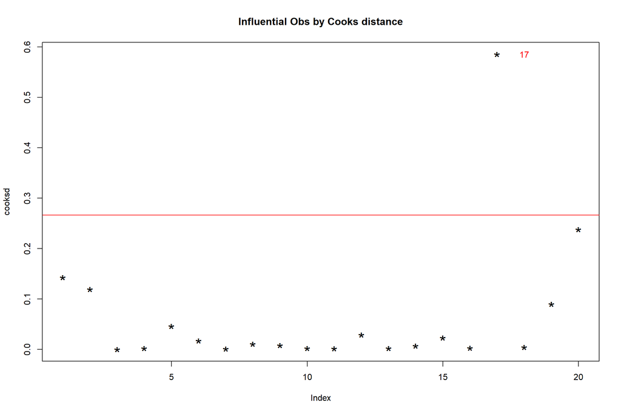

```r
PElin <- lm(logAbundance ~ logSize, data = PEbinned2)
cooksd <- cooks.distance(PElin)
plot(cooksd, pch="*", cex=2, main="Influential Obs by Cooks distance")  # plot cook's distance
abline(h = 4*mean(cooksd, na.rm=T), col="red")  # add cutoff line
text(x=1:length(cooksd)+1, y=cooksd, labels=ifelse(cooksd>4*mean(cooksd, na.rm=T),names(cooksd),""), col="red")  # add labels
```

Extract outliers

```r
influential <- as.numeric(names(cooksd)[(cooksd > 4*mean(cooksd, na.rm=T))])  # influential row numbers
head(PEbinned2[influential, ])  # influential observations.
```

```
##             cut_point bin_count    bin_prop              cut cut.numeric
## 17 < 647.847899999999         1 0.002439024 647.847899999999    647.8479
##    logAbundance  logSize
## 17    -2.612784 2.811473
```

```r
trimmedPE <- PEbinned2 %>%
  filter(cut_point != c("< 647.847899999999")
) %>%
  mutate(polymer = "PE")

PElin <- lm(logAbundance ~ logSize, data = trimmedPE)
PElin.summ <- summary(PElin)
PElin.summ
```

```
##
## Call:
## lm(formula = logAbundance ~ logSize, data = trimmedPE)
##
## Residuals:
##      Min       1Q   Median       3Q      Max
## -0.28498 -0.06266  0.01728  0.07469  0.25909
##
## Coefficients:
##             Estimate Std. Error t value Pr(>|t|)
## (Intercept)   4.6513     0.4683   9.932 1.71e-08 ***
## logSize      -2.3440     0.1786 -13.124 2.53e-10 ***
## ---
## Signif. codes:  0 '***' 0.001 '**' 0.01 '*' 0.05 '.' 0.1 ' ' 1
##
## Residual standard error: 0.1377 on 17 degrees of freedom
## Multiple R-squared:  0.9102, Adjusted R-squared:  0.9049
## F-statistic: 172.2 on 1 and 17 DF,  p-value: 2.527e-10
```

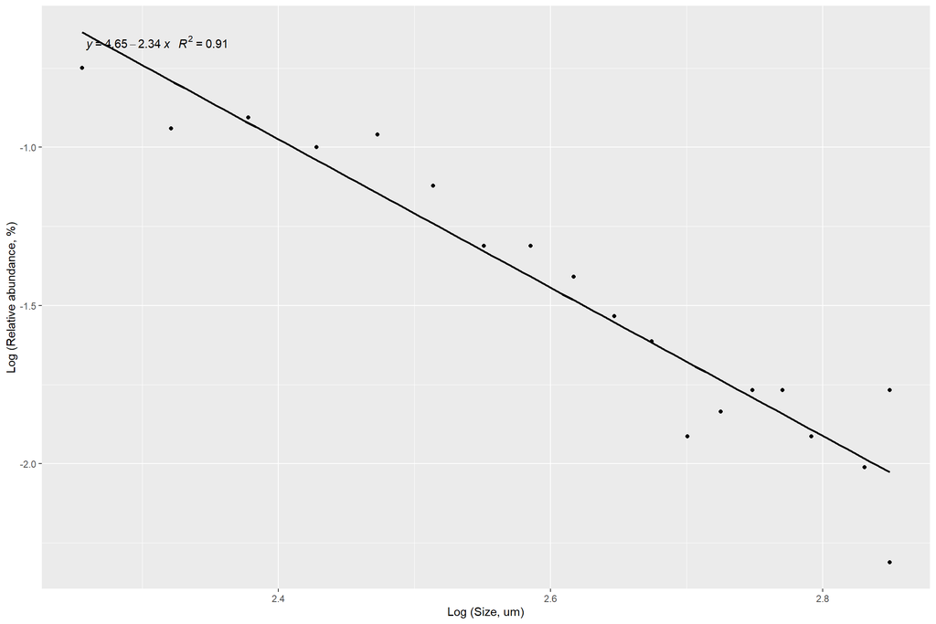

```r
ggplot(data = trimmedPE, aes(x = logSize, y = logAbundance)) +
   geom_smooth(method = "lm", se=FALSE, color="black", formula = my.formula) +
   stat_poly_eq(formula = my.formula,
                aes(label = paste(..eq.label.., ..rr.label.., sep = "~~~")),
                parse = TRUE) +
   geom_point() +
  xlab("Log (Size, um)") +
  ylab("Log (Relative abundance, %)")
```

# 3 All Polymers

## 3.1 Plot individual polymers

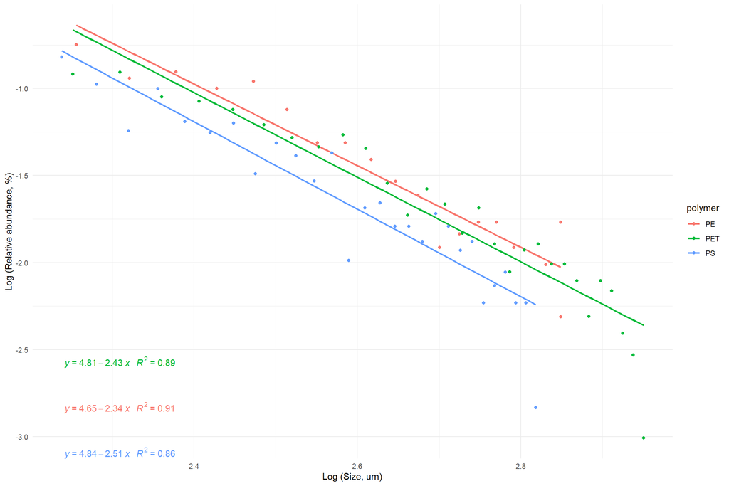

```r
allPolymers <- rbind.data.frame(trimmedPE, trimmedPET, trimmedPS)

allPolymers %>%
ggplot(aes(x = logSize, y = logAbundance, color = polymer, fill = polymer)) +
   geom_smooth(method = "lm", se=FALSE, formula = my.formula) +
   stat_poly_eq(formula = my.formula,
                aes(label = paste(..eq.label.., ..rr.label.., sep = "~~~")),
                label.y = c(0.1,0.2, 0,3),
                parse = TRUE) +
   geom_point() +
  xlab("Log (Size, um)") +
  ylab("Log (Relative abundance, %)") +
  theme_minimal()
```

## 3.2 Calculate alpha for all polymers combined

### 3.2.1 Untrimmed

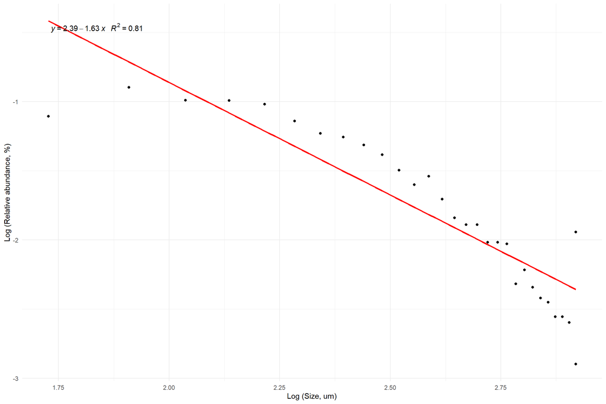

```r
#determine lower and upper end based on maximum R^2 (iteration required)
all_cut <- distributions# %>%
  #filter(Size_um >150 & Size_um <1000)

#cut into bins
#allwinsors <- rbin_winsorize(all_cut, polymer, Size_um, 20)
allwinsors <- rbin_winsorize(all_cut, polymer, Size_um, 30, winsor_rate = 0.01)
#save as dataframe
allbinned <- as.data.frame(allwinsors$bins) %>%
  dplyr::select(c(cut_point, bin_count, bin_prop))

#strip of characters
allbinned$cut <- gsub("[^0-9.-]","",allbinned$cut_point)
 #convert to numeric
allbinned2 <- allbinned %>%
  mutate(cut.numeric = as.numeric(cut)) %>%
  mutate(logAbundance = log10(bin_prop),
         logSize = log10(cut.numeric))

## model
library(ggpmisc)
my.formula <- y ~ x
p <- ggplot(data = allbinned2, aes(x = logSize, y = logAbundance)) +
   geom_smooth(method = "lm", se=FALSE, color="red", formula = my.formula) +
   stat_poly_eq(formula = my.formula,
                aes(label = paste(..eq.label.., ..rr.label.., sep = "~~~")),
                parse = TRUE) +
   geom_point() +
  xlab("Log (Size, um)") +
  ylab("Log (Relative abundance, %)") +
  theme_minimal()
p
```

### 3.2.2 Trimmed

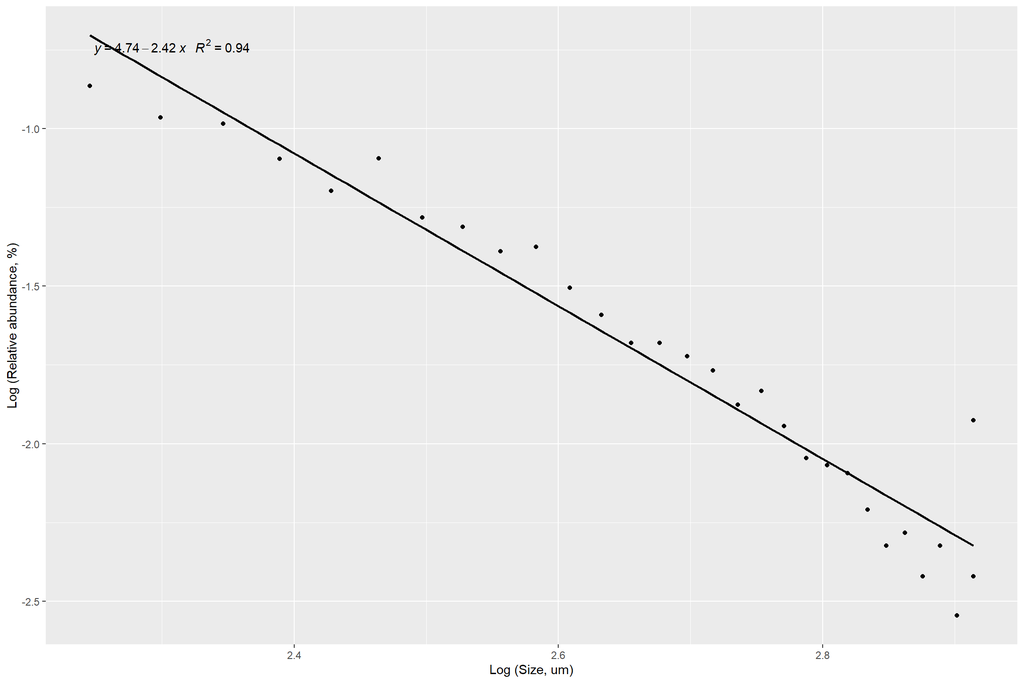

```r
#determine lower and upper end based on maximum R^2 (iteration required)
all_cut <- distributions %>%
  filter(Size_um >150 & Size_um <1000)

#cut into bins
#allwinsors <- rbin_winsorize(all_cut, polymer, Size_um, 20)
allwinsors <- rbin_winsorize(all_cut, polymer, Size_um, 30, winsor_rate = 0.01)
#save as dataframe
allbinned <- as.data.frame(allwinsors$bins) %>%
  dplyr::select(c(cut_point, bin_count, bin_prop))

#strip of characters
allbinned$cut <- gsub("[^0-9.-]","",allbinned$cut_point)
 #convert to numeric
allbinned2 <- allbinned %>%
  mutate(cut.numeric = as.numeric(cut)) %>%
  mutate(logAbundance = log10(bin_prop),
         logSize = log10(cut.numeric))

## model
library(ggpmisc)
my.formula <- y ~ x
p <- ggplot(data = allbinned2, aes(x = logSize, y = logAbundance)) +
   geom_smooth(method = "lm", se=FALSE, color="black", formula = my.formula) +
   stat_poly_eq(formula = my.formula,
                aes(label = paste(..eq.label.., ..rr.label.., sep = "~~~")),
                parse = TRUE) +
   geom_point() +
  xlab("Log (Size, um)") +
  ylab("Log (Relative abundance, %)")
p
```

#### Remove outliers

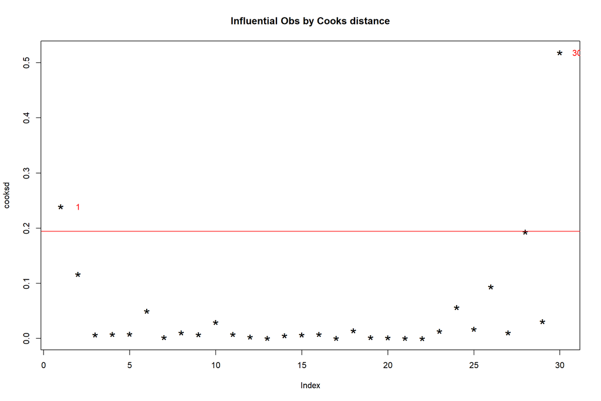

```r
alllin <- lm(logAbundance ~ logSize, data = allbinned2)
cooksd <- cooks.distance(alllin)
plot(cooksd, pch="*", cex=2, main="Influential Obs by Cooks distance")  # plot cook's distance
abline(h = 4*mean(cooksd, na.rm=T), col="red")  # add cutoff line
text(x=1:length(cooksd)+1, y=cooksd, labels=ifelse(cooksd>4*mean(cooksd, na.rm=T),names(cooksd),""), col="red")  # add labels
```

Extract outliers

```r
influential <- as.numeric(names(cooksd)[(cooksd > 4*mean(cooksd, na.rm=T))])  # influential row numbers
head(allbinned2[influential, ])  # influential observations.
```

```
##              cut_point bin_count   bin_prop              cut cut.numeric
## 1   < 175.925733333333       288 0.13655761 175.925733333333    175.9257
## 30 >= 820.422266666667        25 0.01185396 820.422266666667    820.4223
##    logAbundance  logSize
## 1    -0.8646841 2.245329
## 30   -1.9261366 2.914037
```

```r
trimmedall <- allbinned2 %>%
  filter(cut_point != c("   < 175.925733333333", ">= 820.422266666667")
) %>%
  mutate(polymer = "all")

alllin <- lm(logAbundance ~ logSize, data = trimmedall)
alllin.summ <- summary(alllin)
alllin.summ
```

```
##
## Call:
## lm(formula = logAbundance ~ logSize, data = trimmedall)
##
## Residuals:
##      Min       1Q   Median       3Q      Max
## -0.21480 -0.05631  0.02889  0.07772  0.15435
##
## Coefficients:
##             Estimate Std. Error t value Pr(>|t|)
## (Intercept)  4.97893    0.26289   18.94   <2e-16 ***
## logSize     -2.51925    0.09861  -25.55   <2e-16 ***
## ---
## Signif. codes:  0 '***' 0.001 '**' 0.01 '*' 0.05 '.' 0.1 ' ' 1
##
## Residual standard error: 0.1012 on 27 degrees of freedom
## Multiple R-squared:  0.9603, Adjusted R-squared:  0.9588
## F-statistic: 652.7 on 1 and 27 DF,  p-value: < 2.2e-16
```

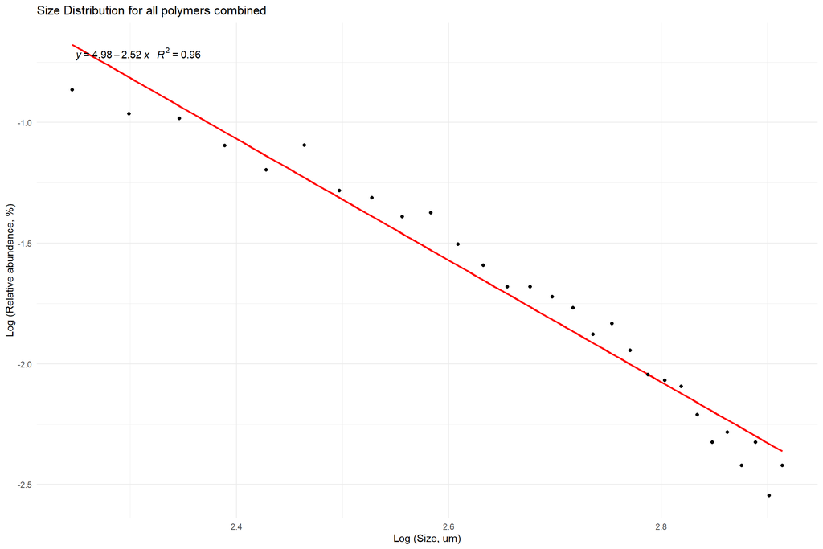

```r
ggplot(data = trimmedall, aes(x = logSize, y = logAbundance)) +
   geom_smooth(method = "lm", se=FALSE, color="red", formula = my.formula) +
   stat_poly_eq(formula = my.formula,
                aes(label = paste(..eq.label.., ..rr.label.., sep = "~~~")),
                parse = TRUE) +
   geom_point() +
  xlab("Log (Size, um)") +
  ylab("Log (Relative abundance, %)") +
  labs(title = "Size Distribution for all polymers combined") +
  theme_minimal()
```

### Visualize as histrogram

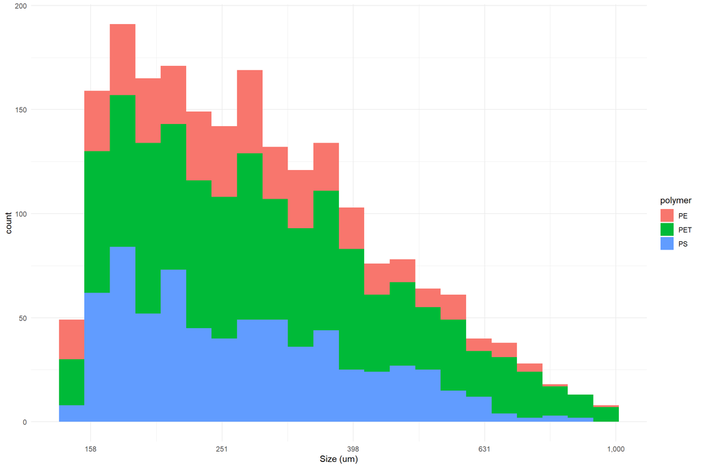

```r
distributions %>%
    filter(Size_um >150 & Size_um <1000) %>%
    ggplot(aes(x = Size_um, fill = polymer)) +
  geom_histogram(bins = 22) +
  #geom_density()+
  scale_x_continuous(name = "Size (um)",breaks = scales::trans_breaks("log10", function(x) 10^x),labels = comma_signif, trans = "log10")+
  theme_minimal()
```

## 3.3 Compare individual and all combined

```r
names <- c("All", "PS", "PE", "PET")

preds <- c(alllin$coefficients[2], PSlin$coefficients[2], PElin$coefficients[2], PETlin$coefficients[2])

stderrors <- c(alllin.summ$coefficients[2,2], PSlin.summ$coefficients[2,2], PElin.summ$coefficients[2,2], PETlin.summ$coefficients[2,2])

R2 <- c(alllin.summ$r.squared, PSlin.summ$r.squared, PElin.summ$r.squared, PETlin.summ$r.squared)

p.values <- c(alllin.summ$coefficients[2,4], PSlin.summ$coefficients[2,4], PElin.summ$coefficients[2,4], PETlin.summ$coefficients[2,4])

summary <- tibble(names,preds, stderrors, R2, p.values)
write.csv(summary,"Concentration data/site-specific distributions/summary_table.csv")
summary
```

```
## # A tibble: 4 x 5
##   names preds stderrors    R2 p.values
##   <chr> <dbl>     <dbl> <dbl>    <dbl>
## 1 All   -2.52    0.0986 0.960 1.89e-20
## 2 PS    -2.51    0.199  0.859 1.42e-12
## 3 PE    -2.34    0.179  0.910 2.53e-10
## 4 PET   -2.43    0.163  0.892 1.47e-14
```

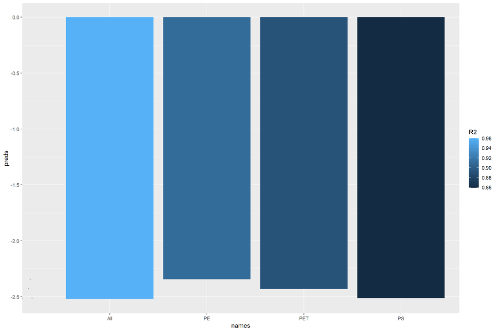

```r
summary %>%
  ggplot(aes(x = names, y = preds, fill = R2)) +
  geom_col() +
  geom_errorbar(aes(xmin = stderrors, xmax = stderrors))
```

## 3.4 Fit distributions

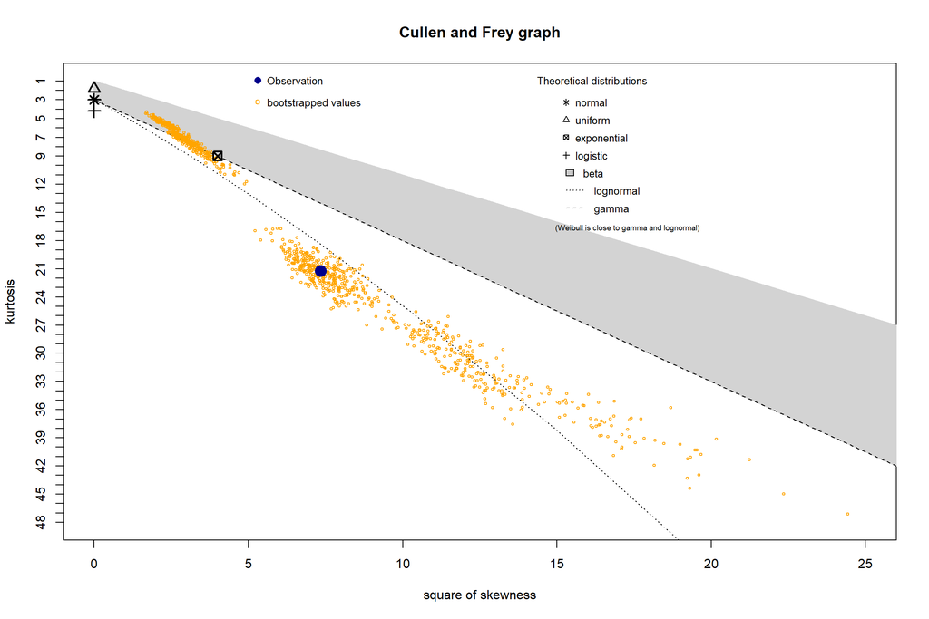

```
## summary statistics
## ------
## min:  5   max:  1960
## median:  153
## mean:  196.5467
## estimated sd:  146.6038
## estimated skewness:  2.708991
## estimated kurtosis:  21.22741
```

```r
#beta test with one polymer
PS <- distributions %>%
  filter(polymer == "PS")
descdist(PS$Size_um, boot = 1000)
```

```r
#fit log-normal distribution
lnorm <- fitdist(PS$Size_um, "lnorm")
```

```
## $start.arg
## $start.arg$meanlog
## [1] 5.053474
##
## $start.arg$sdlog
## [1] 0.6770176
##
##
## $fix.arg
## NULL
```

```r
summary(lnorm)
```

```
## Fitting of the distribution ' lnorm ' by maximum likelihood
## Parameters :
##          estimate Std. Error
## meanlog 5.0534736 0.01836497
## sdlog   0.6770176 0.01298587
## Loglikelihood:  -8265.919   AIC:  16535.84   BIC:  16546.27
## Correlation matrix:
##         meanlog sdlog
## meanlog       1     0
## sdlog         0     1
```

```r
#fit gamma distribution
gamma <- fitdist(PS$Size_um, "gamma")
```

```
## $start.arg
## $start.arg$shape
## [1] 1.798709
##
## $start.arg$rate
## [1] 0.009151557
##
##
## $fix.arg
## NULL
```

```r
summary(gamma)
```

```
## Fitting of the distribution ' gamma ' by maximum likelihood
## Parameters :
##         estimate  Std. Error
## shape 2.35163167 0.082996794
## rate  0.01196295 0.000467178
## Loglikelihood:  -8310.168   AIC:  16624.34   BIC:  16634.76
## Correlation matrix:
##           shape      rate
## shape 1.0000000 0.8931441
## rate  0.8931441 1.0000000
```

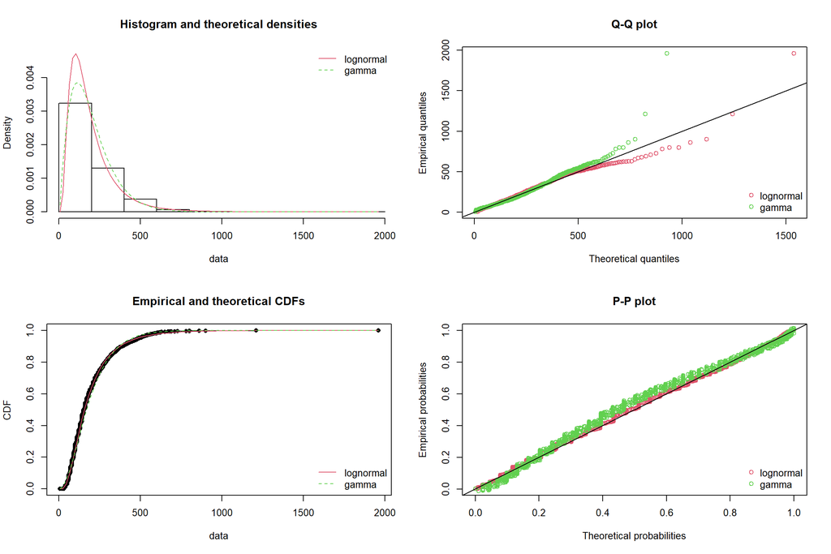

```r
par(mfrow = c(2,2))
plot.legend <- c("lognormal", "gamma")
denscomp(list(lnorm, gamma), legendtext = plot.legend)
qqcomp(list(lnorm, gamma), legendtext = plot.legend)
cdfcomp(list(lnorm, gamma), legendtext = plot.legend)
ppcomp(list(lnorm, gamma), legendtext = plot.legend)
```

Which distributions fits the data best?

```r
gofstat(list(lnorm, gamma), fitnames = plot.legend)
```

```
## Goodness-of-fit statistics
##                               lognormal      gamma
## Kolmogorov-Smirnov statistic 0.02789497 0.07307797
## Cramer-von Mises statistic   0.14929895 1.55700811
## Anderson-Darling statistic   1.10141746 8.98176779
##
## Goodness-of-fit criteria
##                                lognormal    gamma
## Akaike's Information Criterion  16535.84 16624.34
## Bayesian Information Criterion  16546.27 16634.76
```